# Statistical Inference Project Part 1

Azmi Mohamed Ridwan

March 28, 2016

## Overview

In this project, the exponential distribution is investigated and compared to the Central Limit Theorem. The exponential distribution can be simulated in R with rexp(n, lambda) where lambda is the rate parameter. The mean of exponential distribution is 1/lambda and the standard deviation is also 1/lambda. lambda will be set to 0.2 for all of the simulations. The target of study is the distribution of averages of 40 exponentials which will be simulated a thousand times.

## Simulations

*Include English explanations of the simulations you ran, with the accompanying R code. Your explanations should make clear what the R code accomplishes.*

The first code snippet sets up the necessary basic variables for the simultation.

```r
set.seed(234)
lambda <- 0.2
n <- 40
num.sim <- 1000
```

Using the exponential distribution function *rexp*, a matrix is created with 1000 rows with the columns containing the 40 exponentials.

```r
sim.matrix <- matrix(rexp(num.sim * n, rate = lambda), num.sim, n)
```

The mean for each row is calculated and a histogram is plotted.

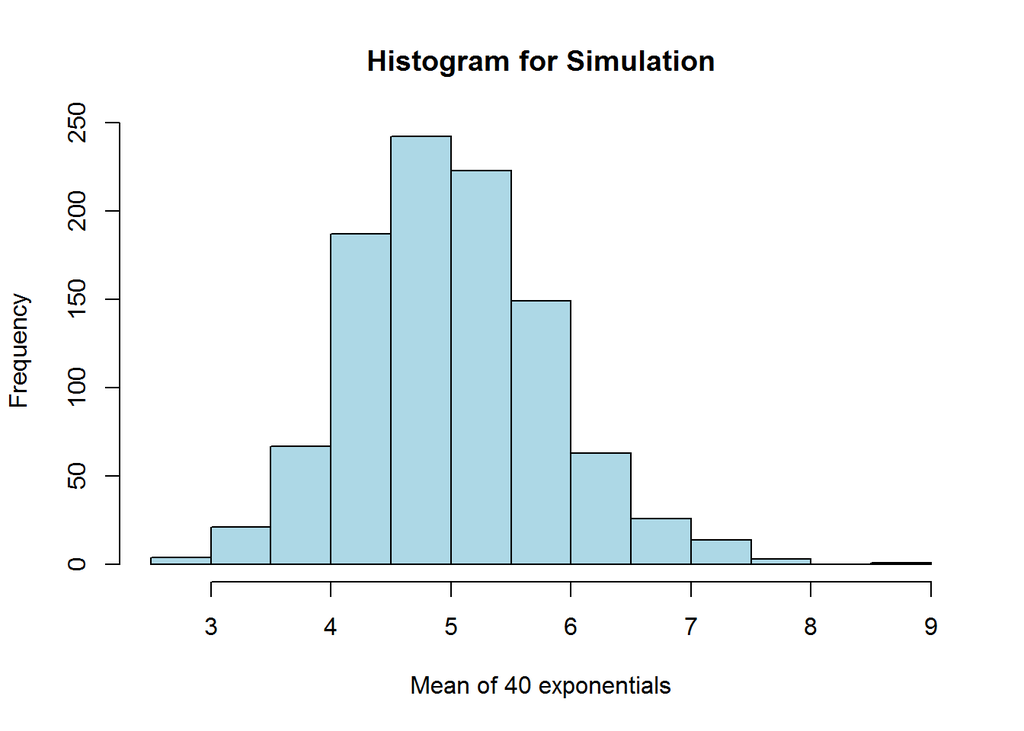

```r
sim.mean <- rowMeans(sim.matrix)
hist(sim.mean, xlab="Mean of 40 exponentials", ylab= "Frequency", col="light blue", main="Histogram for Simulation")
```

## Sample Mean versus Theoretical Mean

*Include figures with titles. In the figures, highlight the means you are comparing. Include text that explains the figures and what is shown on them, and provides appropriate numbers.*

The mean of the simulation and the theoretical mean are calculated here. The simulation mean values is then added to the histogram

```r
actual.mean = mean(sim.mean)
theoretical.mean = 1/lambda
print(c(actual.mean, theoretical.mean))
```

```
## [1] 5.001573 5.000000
```

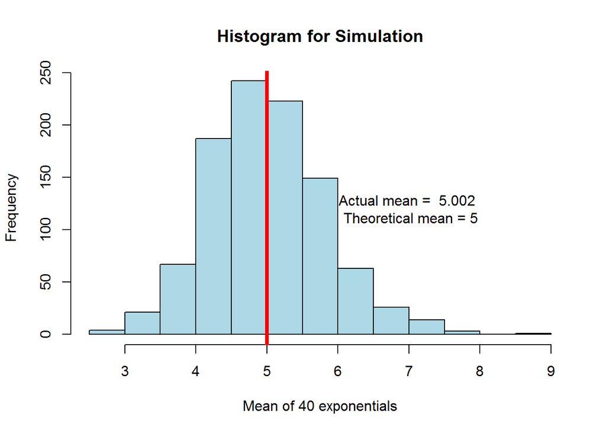

```r
hist(sim.mean, xlab="Mean of 40 exponentials", ylab= "Frequency", col="light blue", main="Histogram for Simulation")
abline(v=actual.mean, lwd="4", col="red")
text(7, 120, paste("Actual mean = ", round(actual.mean,3), "\n Theoretical mean = 5" ), col="black")
```

The mean of the simulation is very close to the theoretical mean.

## Sample Variance versus Theoretical Variance

*Include figures (output from R) with titles. Highlight the variances you are comparing. Include text that explains your understanding of the differences of the variances.*

The actual and theoretical variance calculations are:

```r
actual.var<- var(sim.mean)
theoretical.var <- (1/lambda)^2/n
```

The actual variance is **0.6631504** and the theoretical variance is **0.625**. Again both values are quite close.

## Distribution

*Via figures and text, explain how one can tell the distribution is approximately normal.*

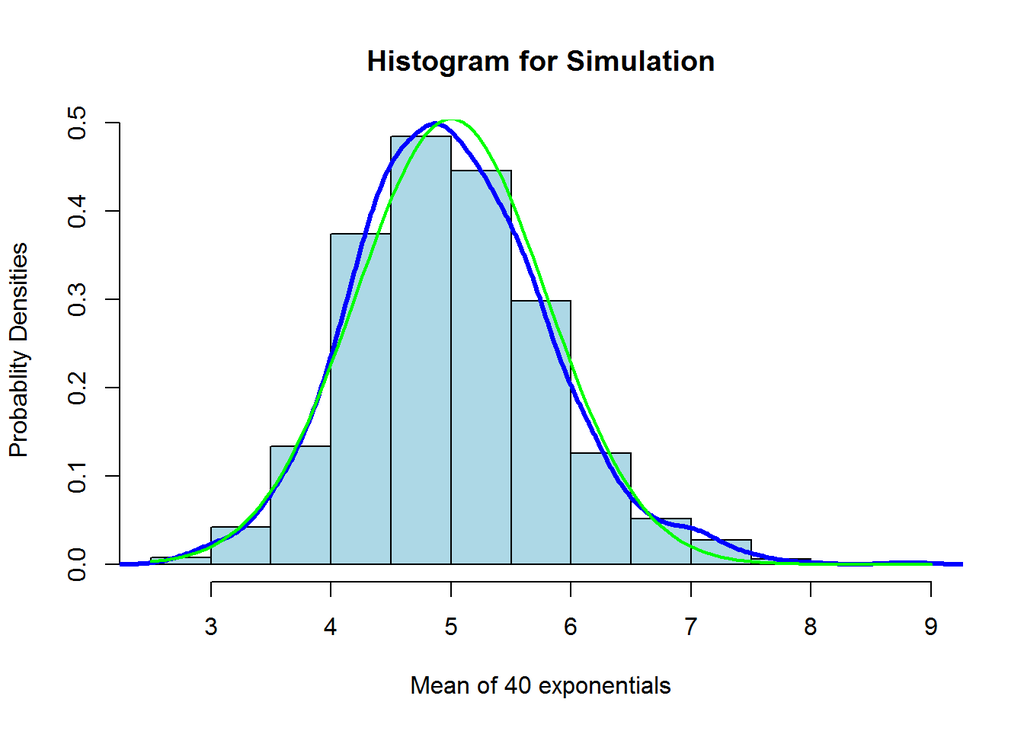

```r
hist(sim.mean, freq = FALSE, breaks = 20, xlab="Mean of 40 exponentials", ylab= "Probablity Densities", col="light blue", main="Histogram for Simulation")
x <- c(0,1)
lines(density(sim.mean), lwd=3, col="blue")
curve(dnorm(x, mean=theoretical.mean, sd=sqrt(theoretical.var)), col="green", lwd=2, add=TRUE, yaxt="n")
```

We can see that the simulation distribution is very close to the theoretical normal distribution.

We can do a Quantile-Quantile plot. We can see the values of the simulations fall close on the diagonal.

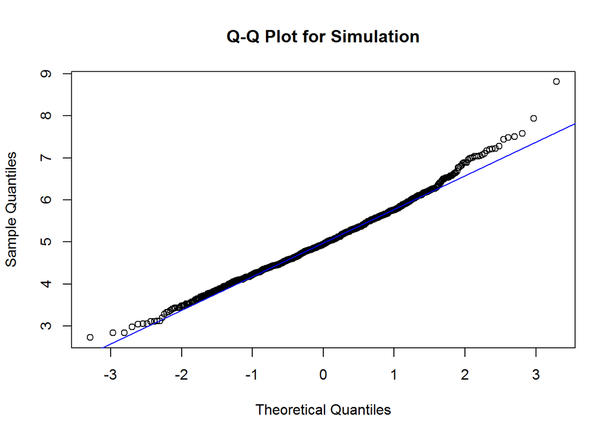

```r
qqnorm(sim.mean, main="Q-Q Plot for Simulation", xlab="Theoretical Quantiles", ylab="Sample Quantiles")
qqline(sim.mean, col="blue")
```

We can also compare the confidence interval. Again, we can see that the 2 values are very close.

```r
actual.ci <- round (mean(sim.mean) + c(-1,1)*1.96*sd(sim.mean)/sqrt(n),3)
theoretical.ci <- theoretical.mean + c(-1,1)*1.96*sqrt(theoretical.var)/sqrt(n)
```

95% confidence interval - **Actual=[4.749, 5.254]**, **Theoretical=[4.755, 5.245]**